# Advanced Methods for Regression and Classification - Exercise 3 Experiment - Dzenan Hamzic, TU Wien

# 1. Ridge Regression:

## 1.a

```r
lm_seq = seq(0,10,0.001)
head(lm_seq)
```

```
[1] 0.000 0.001 0.002 0.003 0.004 0.005
```

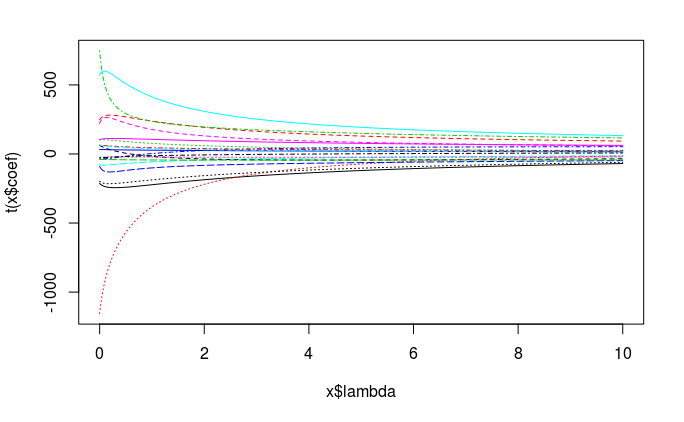

```r
model.ridge <- lm.ridge(Salary ~ ., data = X_train, lambda = lm_seq)
#head(model.ridge)
plot(model.ridge, main="Schrinkaga of Ridge Regression")
```

```r
select(model.ridge)
```

```
modified HKB estimator is 0.7463882
modified L-W estimator is 19.59409
smallest value of GCV  at 0.322
```

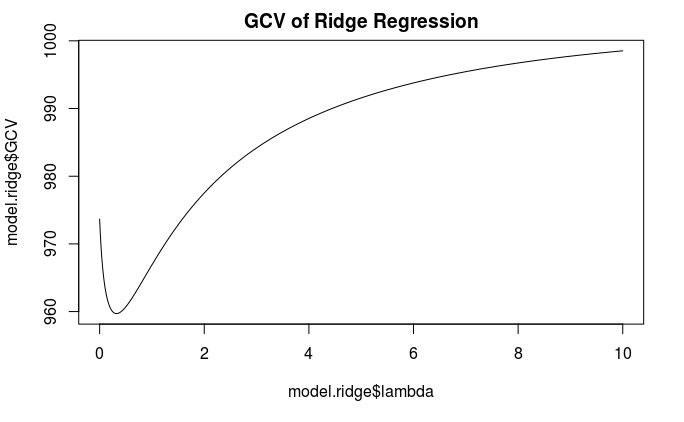

```r
plot(model.ridge$lambda, model.ridge$GCV, type = "l", main="GCV of Ridge Regression")
```

#### Optimal lambda & minimal GCV

```r
#head(model.ridge$GCV[,2])
#plot(model.ridge$GCV)
min_gcv <- min(model.ridge$GCV)
# find index of smallest GCV
min_gcv_index <- match(min_gcv, model.ridge$GCV)
model.ridge$GCV[323]
```

```
   0.322
959.7083
```

#### INTEPRETATION

Generalized cross validation GCV is a good approximation of the Leave one out CV by linear fits with quadratic errors. In this case, the optimal lambda seems to be 0.322 (see both plots above) with GCV of 959.7083.

## 1.b

```r
model.ridge.optimal <- lm.ridge(Salary ~ ., data = X_train, lambda = 0.322)
```

#### Regression coefficients

```r
model.ridge.optimal$coef
```

```
     AtBat       Hits      HmRun       Runs        RBI      Walks      Years     CAtBat
-243.83684  277.71782   96.34941  -25.52128  -74.54042  112.10774   19.12622 -680.08896
     CHits     CHmRun      CRuns       CRBI     CWalks     League   Division    PutOuts
 339.96845 -127.00449  554.47799  246.56462 -212.87731   54.76782  -41.27468   30.00531
   Assists     Errors  NewLeague
  49.71976  -20.76523  -20.88672
```

## 1.c

```r
# predict with optimal ridge parameters
prediction <- as.matrix(cbind(const=1,X_test)) %*% coef(model.ridge.optimal)
head(prediction)
```

```
                      [,1]
-Alan Ashby       305.6254
-Andres Galarraga 523.0791
-Al Newman        373.2874
-Andre Thornton   496.4768
-Alan Trammell    959.7940
-Alex Trevino     339.8108
```

### MSE

```r
#model.ridge.optimal.predict <- predict(model.ridge.optimal , newdata = X_test)
#head(model.ridge.optimal.predict)
mean((y_test - prediction[,1]) ^ 2)
```

```
[1] 112372
```

### MSE with using modified HKB estimator is 0.7463882 as lambda

```r
model.ridge.optimal2 <- lm.ridge(Salary ~ ., data = X_train, lambda = 0.7463882)
# predict with optimal ridge parameters
prediction2 <- as.matrix(cbind(const=1,X_test)) %*% coef(model.ridge.optimal2)
mean((y_test - prediction2[,1]) ^ 2)
```

```
[1] 110856.5
```

### Graphically

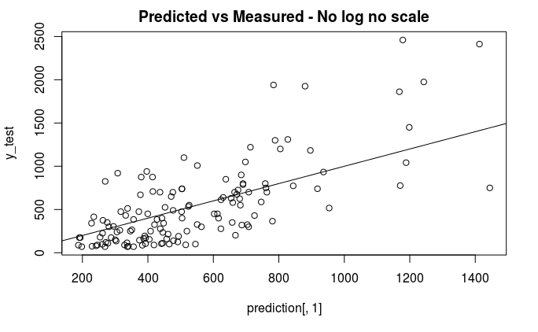

```r
plot(prediction[,1], y_test, title("Predicted vs Measured - No log no scale"))
abline(c(0,1))
```

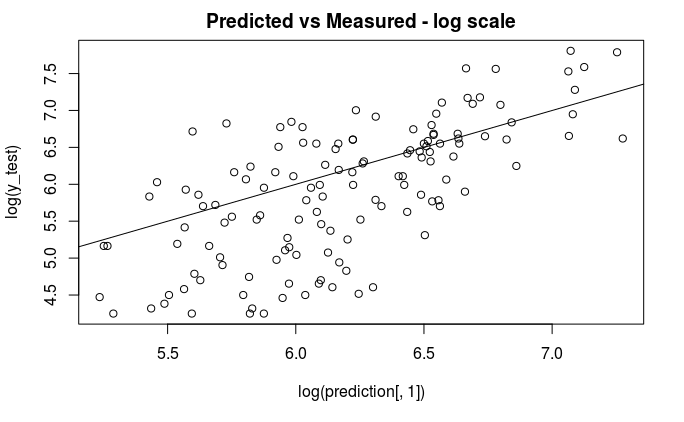

```r
plot(log(prediction[,1]), log(y_test), title("Predicted vs Measured - log scale"))
abline(c(0,1))
```

```r
#require(gridExtra)
#plot1 <- plot(prediction[,1], y_test)
#plot2 <- plot(log(prediction[,1]), log(y_test))
#grid.arrange(plot1, plot2, ncol=2)
```

#### INTEPRETATION

Ridge regression beats standard PCR on MSE. However, best subset PCR regression still performs significantly better. Graphically, ridge shows decent fit but still with quite high predictive deviation.